# Exercise 6.6.10 - GLM Analysis/‘Pruning’; Interactions

W. Mangrobang

September 08, 2018

### Problem Statement

Complete the analysis of the frequency and severity models, dropping variables that do not add predictive value.

Note that it is not advisable to drop more than one variable at a time. Two variables may appear to lack predictive power, but when one is dropped, the other’s value may increase.

Keep in mind that the test does not answer the question “Is this variable valuable?” but rather “In the presence of the other variables, does this variable provide additional value?”

```r
# libraries
library(caret)  # ML
library(glmnet)  # regressions
library(rpart)  # decision trees
library(rpart.plot)  # tree plotting
library(tidyverse)  # tidy data and plots
library(kableExtra)  # pretty tables
library(pROC)  #ROC plots and metrics
library(scales)  #scaling and other helpers
library(stats)  #AIC/BIC
library(gridExtra)  # Gridded plots

# # Set classification thresholds thresh_1 <- .50 thresh_2 <- .75 thresh_3
# <- .90
```

*Re-run Chunks 13-24 from the Section notebook*

Run CHUNK 13 to load the AutoClaim dataset and summarize the variables.

```r
# CHUNK 13
library(cplm)
data(AutoClaim)
summary(AutoClaim)
```

```
##    POLICYNO            PLCYDATE            CLM_FREQ5         CLM_AMT5
##  Length:10296       Min.   :1993-04-17   Min.   :0.0000   Min.   :    0
##  Class :character   1st Qu.:1994-11-08   1st Qu.:0.0000   1st Qu.:    0
##  Mode  :character   Median :1996-05-11   Median :0.0000   Median :    0
##                     Mean   :1996-05-11   Mean   :0.8004   Mean   : 4032
##                     3rd Qu.:1997-11-13   3rd Qu.:2.0000   3rd Qu.: 4646
##                     Max.   :1999-07-07   Max.   :5.0000   Max.   :57037
##
##     CLM_AMT          KIDSDRIV         TRAVTIME            CAR_USE
##  Min.   :     0   Min.   :0.0000   Min.   :  5.00   Private   :6507
##  1st Qu.:     0   1st Qu.:0.0000   1st Qu.: 22.00   Commercial:3789
##  Median :     0   Median :0.0000   Median : 33.00
##  Mean   :  1510   Mean   :0.1694   Mean   : 33.42
##  3rd Qu.:  1133   3rd Qu.:0.0000   3rd Qu.: 44.00
##  Max.   :123247   Max.   :4.0000   Max.   :142.00
##
##     BLUEBOOK        RETAINED         NPOLICY             CAR_TYPE
##  Min.   : 1500   Min.   : 1.000   Min.   :1.000   Panel Truck: 853
##  1st Qu.: 9200   1st Qu.: 1.000   1st Qu.:1.000   Pickup     :1772
##  Median :14405   Median : 4.000   Median :1.000   Sedan      :2693
##  Mean   :15666   Mean   : 5.328   Mean   :1.695   Sports Car :1176
##  3rd Qu.:20900   3rd Qu.: 7.000   3rd Qu.:2.000   SUV        :2881
##  Max.   :69740   Max.   :25.000   Max.   :9.000   Van        : 921
##
##  RED_CAR    REVOLKED      MVR_PTS       CLM_FLAG        AGE
##  no :7327   No :9036   Min.   : 0.000   No :7556   Min.   :16.00
##  yes:2969   Yes:1260   1st Qu.: 0.000   Yes:2740   1st Qu.:39.00
##                        Median : 1.000              Median :45.00
##                        Mean   : 1.709              Mean   :44.84
##                        3rd Qu.: 3.000              3rd Qu.:51.00
##                        Max.   :13.000              Max.   :81.00
##
##     HOMEKIDS           YOJ            INCOME       GENDER   MARRIED
##  Min.   :0.0000   Min.   : 0.00   Min.   :     0   F:5540   No :4109
##  1st Qu.:0.0000   1st Qu.: 9.00   1st Qu.: 27621   M:4756   Yes:6187
##  Median :0.0000   Median :11.00   Median : 53564
##  Mean   :0.7199   Mean   :10.48   Mean   : 61610
##  3rd Qu.:1.0000   3rd Qu.:13.00   3rd Qu.: 86214
##  Max.   :5.0000   Max.   :23.00   Max.   :367030
##                   NA's   :548     NA's   :569
##  PARENT1            JOBCLASS            MAX_EDUC       HOME_VAL
##  No :8957   Blue Collar :2288   <High School:1512   Min.   :     0
##  Yes:1339   Clerical    :1588   Bachelors   :2822   1st Qu.:     0
##             Professional:1409   High School :2950   Median :160739
##             Manager     :1257   Masters     :2078   Mean   :154603
##             Lawyer      :1031   PhD         : 934   3rd Qu.:238288
##             Student     : 896                       Max.   :885282
##             (Other)     :1827                       NA's   :574
##     SAMEHOME         AREA        IN_YY
##  Min.   :-3.000   Rural:2072   Mode :logical
##  1st Qu.: 1.000   Urban:8224   FALSE:7484
##  Median : 8.000                TRUE :2812
##  Mean   : 8.301
##  3rd Qu.:12.000
##  Max.   :28.000
##  NA's   :639
```

```r
`?`(AutoClaim)
```

RUn CHUNK 14 to convert CLM_FLAG to 0 or 1 and set aside two variables of limited use.

```r
# CHUNK 14
AutoClaim$CLM_FLAG_NUM <- ifelse(AutoClaim$CLM_FLAG == "Yes", 1, 0)
not_used_vars <- c("POLICYNO", "IN_YY")
```

```r
str(AutoClaim)
```

```
## 'data.frame':    10296 obs. of  30 variables:
##  $ POLICYNO    : chr  "00000160" "00024836" "00028046" "00028960" ...
##  $ PLCYDATE    : Date, format: "1997-11-08" "1998-07-29" ...
##  $ CLM_FREQ5   : int  2 0 0 2 0 2 0 0 1 0 ...
##  $ CLM_AMT5    : int  4461 0 0 38690 0 19217 0 0 3295 0 ...
##  $ CLM_AMT     : int  0 0 0 0 0 0 2946 0 6477 0 ...
##  $ KIDSDRIV    : int  0 0 0 0 0 0 0 0 1 0 ...
##  $ TRAVTIME    : int  14 22 26 5 32 36 46 33 21 30 ...
##  $ CAR_USE     : Factor w/ 2 levels "Private","Commercial": 1 2 1 1 1 1 2 1 1 2 ...
##  $ BLUEBOOK    : int  14230 14940 21970 4010 15440 18000 17430 8780 18930 5900 ...
##  $ RETAINED    : int  11 1 1 4 7 1 1 1 6 10 ...
##  $ NPOLICY     : int  1 1 1 1 1 1 1 1 1 1 ...
##  $ CAR_TYPE    : Factor w/ 6 levels "Panel Truck",..: 3 3 6 5 3 5 4 5 3 5 ...
##  $ RED_CAR     : Factor w/ 2 levels "no","yes": 2 2 2 1 2 1 1 1 1 1 ...
##  $ REVOLKED    : Factor w/ 2 levels "No","Yes": 1 1 1 1 1 2 1 1 1 1 ...
```

[output cut: 16 more lines]

Run CHUNK 15 to create a function that provides a one-way plot of a categorical variable.

```
## $dframe
##   Factor SumWeight SumActual AverageActual
## 2     no      7327      1968     0.2685956
## 1    yes      2969       772     0.2600202
##
## $plot_table
```

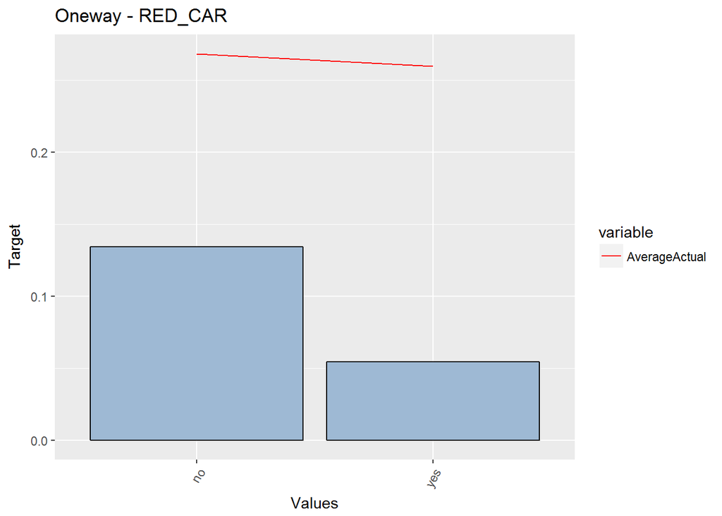

```r
# CHUNK 15
library(data.table)
# the inputs are the dataset, the predictor (x), the target (y), and the
# weights, if any
oneway_plot <- function(dataset, x, y, weight = NULL) {
    Weight = ifelse(is.null(weight), 1, dataset[, weight])  #sets the weights to 1 if none provided
    modeldata <- data.frame(Weight = Weight, Actual = dataset[, y], Factor = as.factor(dataset[,
        x]))

    dframe <- as.data.frame(data.table(modeldata)[, .(SumWeight = sum(Weight),
        SumActual = sum(Actual), AverageActual = sum(Actual)/sum(Weight)), by = Factor])
    dframe <- dframe[order(dframe$Factor), ]
    dframe.melt <- melt(dframe[, c(1, 4)], id = c("Factor"))
    weight_max <- max(dframe$SumWeight)
    resp_max <- max(dframe.melt$value)

    plot1 <- ggplot(dframe, aes(x = Factor, y = SumWeight, group = 1)) + geom_bar(stat = "identity",
        aes(x = Factor, y = SumWeight * 0.5 * (resp_max)/(weight_max)), col = "black",
        fill = "#9EB9D4") + geom_line(data = dframe.melt, aes(x = Factor, y = value,
        color = variable, group = variable)) + scale_colour_manual(values = c("red")) +
        theme(axis.text.x = element_text(angle = 60, hjust = 1)) + labs(title = paste("Oneway",
        "-", x), x = "Values", y = "Target")

    return(list(dframe = dframe, plot_table = plot1))
}
# Note you can use plotly() instead to make interactive graphs

# Example
oneway_plot(dataset = AutoClaim, x = "RED_CAR", y = "CLM_FLAG_NUM", weight = "NPOLICY")
```

Run CHUNK 16 to make all the plots for the categorical variables.

```
## [[1]]
## [[1]]$dframe
##       Factor SumWeight SumActual AverageActual
## 1    Private      6507      1431     0.2199170
## 2 Commercial      3789      1309     0.3454737
##
## [[1]]$plot_table
```

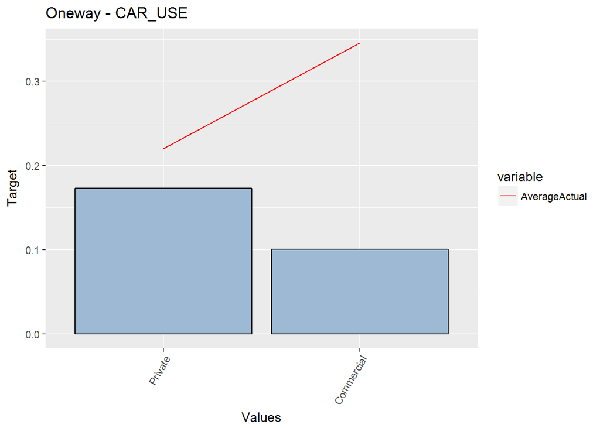

```
##
##
## [[2]]
## [[2]]$dframe
##        Factor SumWeight SumActual AverageActual
## 5 Panel Truck       853       225     0.2637749
## 6      Pickup      1772       555     0.3132054
## 1       Sedan      2693       464     0.1722986
## 4  Sports Car      1176       405     0.3443878
## 3         SUV      2881       840     0.2915654
## 2         Van       921       251     0.2725299
##
## [[2]]$plot_table
```

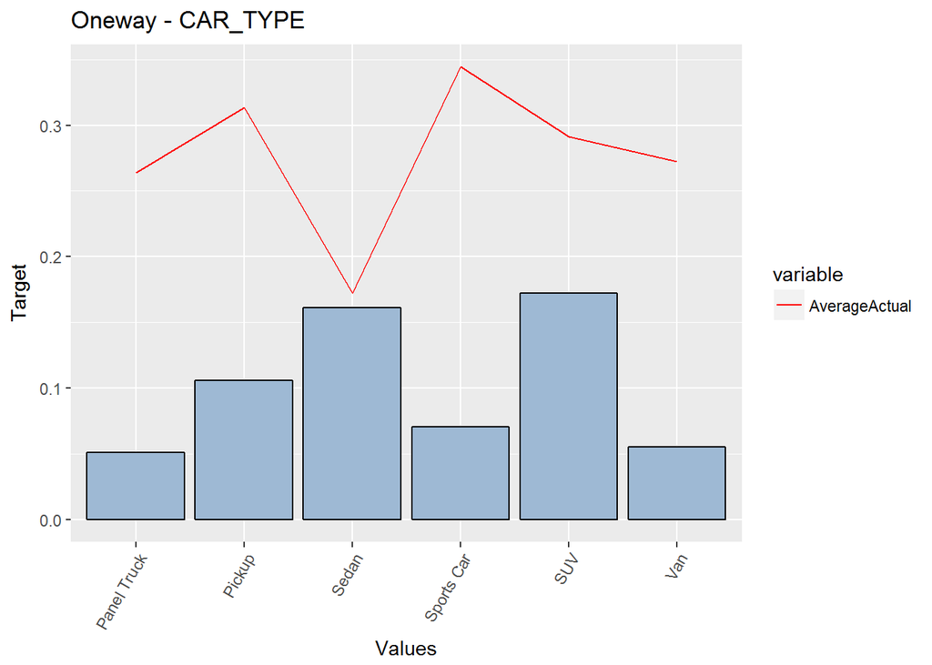

```
##
##
## [[3]]
## [[3]]$dframe
##   Factor SumWeight SumActual AverageActual
## 1     No      9036      2172     0.2403718
## 2    Yes      1260       568     0.4507937
##
## [[3]]$plot_table
```

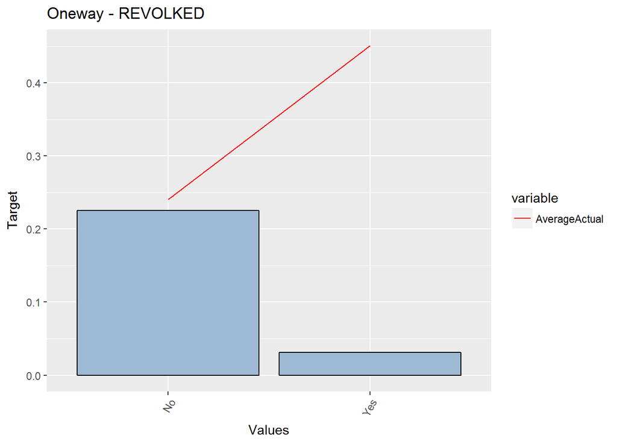

```
##
##
## [[4]]
## [[4]]$dframe
##   Factor SumWeight SumActual AverageActual
## 2      F      5540      1524     0.2750903
## 1      M      4756      1216     0.2556770
##
## [[4]]$plot_table
```

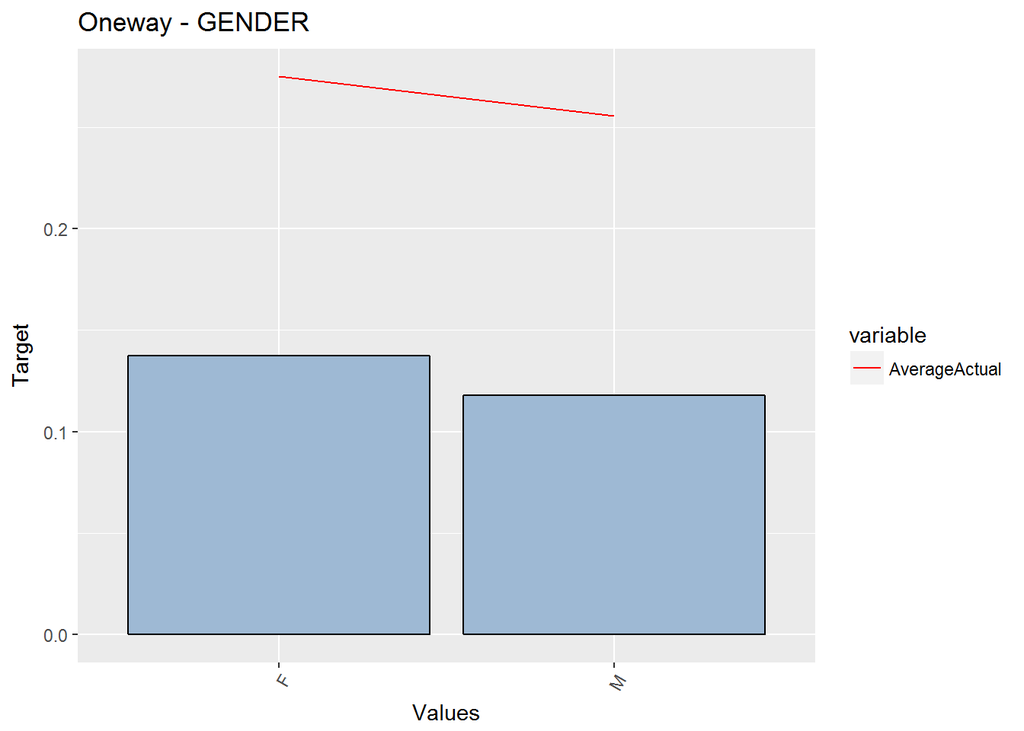

```
##
##
## [[5]]
## [[5]]$dframe
##   Factor SumWeight SumActual AverageActual
## 1     No      4109      1381     0.3360915
## 2    Yes      6187      1359     0.2196541
##
## [[5]]$plot_table
```

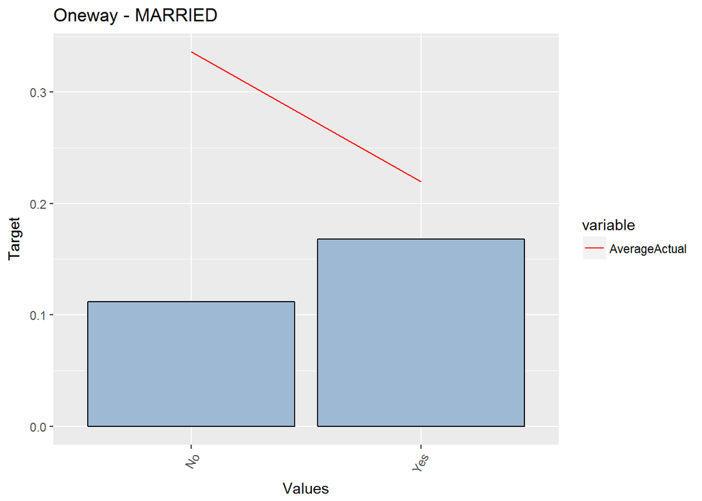

```
##
##
## [[6]]
## [[6]]$dframe
##   Factor SumWeight SumActual AverageActual
## 1     No      8957      2143     0.2392542
## 2    Yes      1339       597     0.4458551
##
## [[6]]$plot_table
```

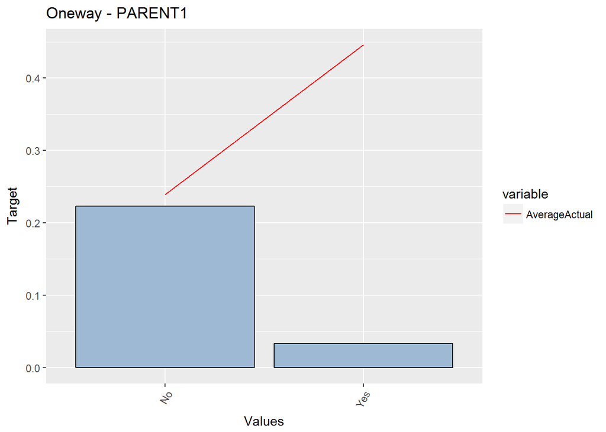

```
##
##
## [[7]]
## [[7]]$dframe
##         Factor SumWeight SumActual AverageActual
## 7      Unknown       665       174     0.2616541
## 2  Blue Collar      2288       803     0.3509615
## 4     Clerical      1588       479     0.3016373
## 5       Doctor       321        37     0.1152648
## 8   Home Maker       841       227     0.2699168
## 6       Lawyer      1031       186     0.1804074
## 3      Manager      1257       170     0.1352426
## 1 Professional      1409       325     0.2306600
## 9      Student       896       339     0.3783482
##
## [[7]]$plot_table
```

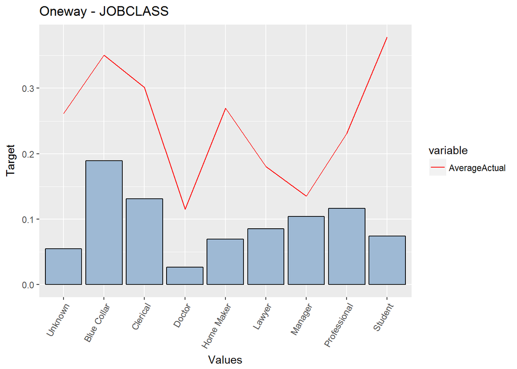

```
##
##
## [[8]]
## [[8]]$dframe
##         Factor SumWeight SumActual AverageActual
## 4 <High School      1512       489     0.3234127
## 3    Bachelors      2822       671     0.2377746
## 2  High School      2950      1022     0.3464407
## 5      Masters      2078       404     0.1944177
## 1          PhD       934       154     0.1648822
##
## [[8]]$plot_table
```

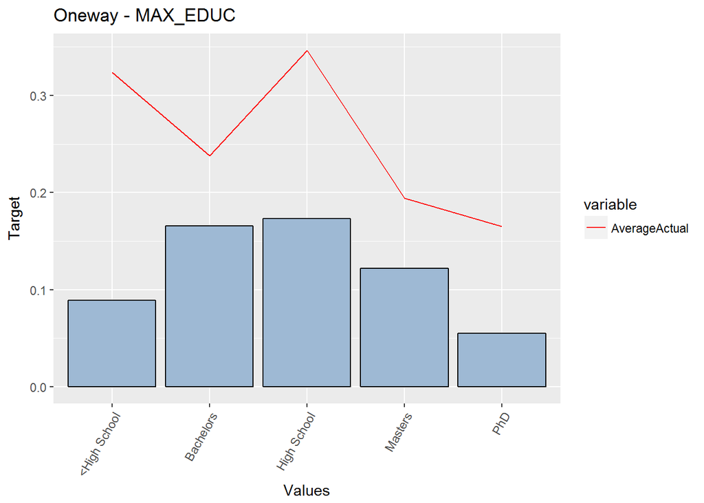

```
##
##
## [[9]]
## [[9]]$dframe
##   Factor SumWeight SumActual AverageActual
## 2  Rural      2072       134    0.06467181
## 1  Urban      8224      2606    0.31687743
##
## [[9]]$plot_table
```

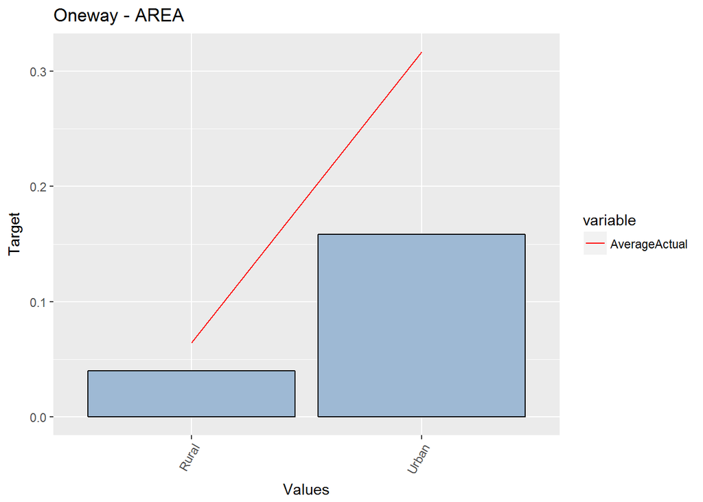

```r
# CHUNK 16
categoricals <- c("CAR_USE", "CAR_TYPE", "REVOLKED", "GENDER", "MARRIED", "PARENT1",
    "JOBCLASS", "MAX_EDUC", "AREA")
lapply(X = categoricals, FUN = function(x) {
    oneway_plot(dataset = AutoClaim, x = x, y = "CLM_FLAG_NUM")
})
```

Run CHUNK 17 to make an equal width bin for BLUEBOOK.`

```
## $dframe
##                 Factor SumWeight SumActual AverageActual
## 3  (1.43e+03,8.32e+03]      2195       764     0.3480638
## 1  (8.32e+03,1.51e+04]      3313       889     0.2683369
## 2   (1.51e+04,2.2e+04]      2547       605     0.2375344
## 4   (2.2e+04,2.88e+04]      1447       339     0.2342778
## 5  (2.88e+04,3.56e+04]       586        94     0.1604096
## 6  (3.56e+04,4.24e+04]       159        37     0.2327044
## 7  (4.24e+04,4.93e+04]        40         9     0.2250000
## 8  (4.93e+04,5.61e+04]         4         1     0.2500000
## 10 (5.61e+04,6.29e+04]         3         2     0.6666667
## 9  (6.29e+04,6.98e+04]         2         0     0.0000000
##
## $plot_table
```

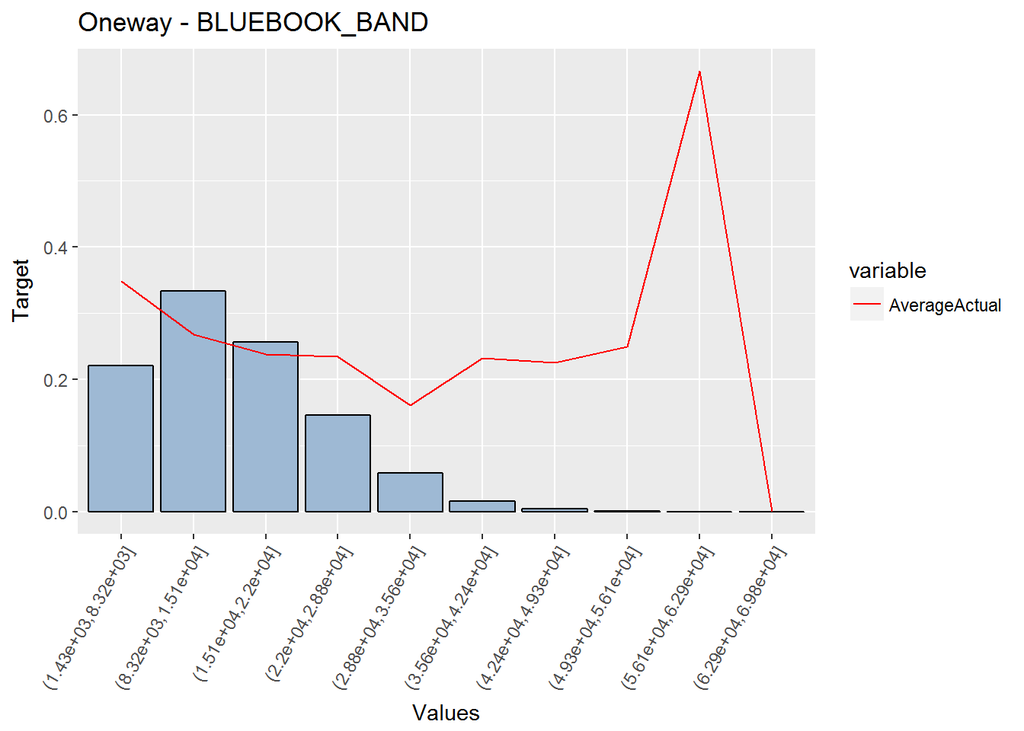

```r
# CHUNK 17
AutoClaim$BLUEBOOK_BAND <- cut(x = AutoClaim$BLUEBOOK, breaks = 10, ordered_result = TRUE)

oneway_plot(dataset = AutoClaim, x = "BLUEBOOK_BAND", y = "CLM_FLAG_NUM")
```

Run CHUNK 18 to make the other plots.

```
## [[1]]
## [[1]]$dframe
##         Factor SumWeight SumActual AverageActual
## 1  (4.86,18.7]      1843       410     0.2224634
## 2  (18.7,32.4]      3212       808     0.2515567
## 3  (32.4,46.1]      3206       904     0.2819713
## 4  (46.1,59.8]      1474       462     0.3134328
## 5  (59.8,73.5]       444       133     0.2995495
## 6  (73.5,87.2]        92        20     0.2173913
## 7   (87.2,101]        18         3     0.1666667
## 8    (101,115]         4         0     0.0000000
## 9    (115,128]         1         0     0.0000000
## 10   (128,142]         2         0     0.0000000
##
## [[1]]$plot_table
```

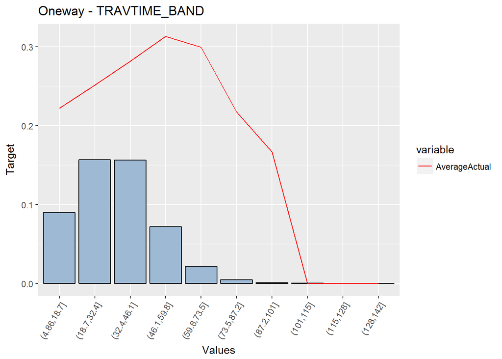

```
##
##
## [[2]]
## [[2]]$dframe
##         Factor SumWeight SumActual AverageActual
## 9  (15.9,22.5]        51        29     0.5686275
## 6    (22.5,29]       346       171     0.4942197
## 3    (29,35.5]      1047       358     0.3419293
## 5    (35.5,42]      2593       775     0.2988816
## 2    (42,48.5]      2763       619     0.2240318
## 4    (48.5,55]      2399       454     0.1892455
## 1    (55,61.5]       843       260     0.3084223
## 7    (61.5,68]       231        68     0.2943723
## 10   (68,74.5]        20         5     0.2500000
## 8  (74.5,81.1]         3         1     0.3333333
##
## [[2]]$plot_table
```

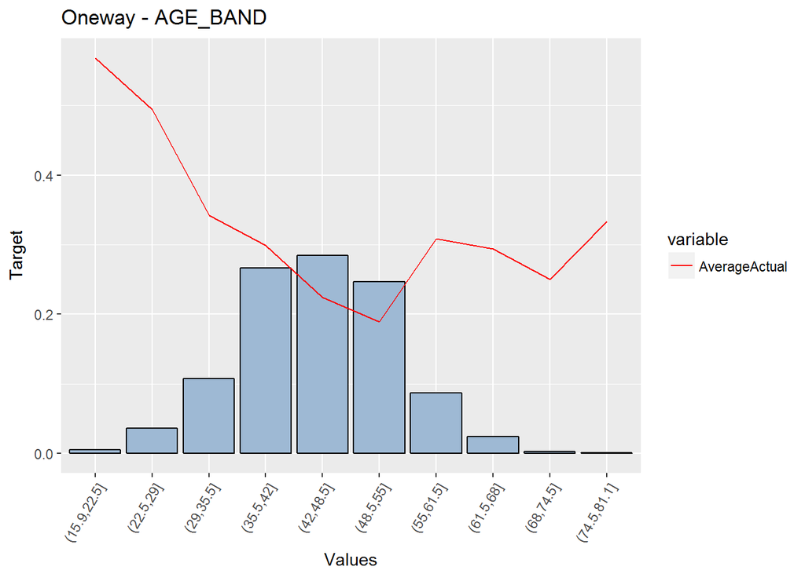

```
##
##
## [[3]]
## [[3]]$dframe
##                 Factor SumWeight SumActual AverageActual
## 3      (-367,3.67e+04]      3288      1097     0.3336375
## 1  (3.67e+04,7.34e+04]      3204       921     0.2874532
## 2   (7.34e+04,1.1e+05]      1892       360     0.1902748
## 5   (1.1e+05,1.47e+05]       795       137     0.1723270
## 6  (1.47e+05,1.84e+05]       324        53     0.1635802
## 7   (1.84e+05,2.2e+05]       144        22     0.1527778
## 9   (2.2e+05,2.57e+05]        57         6     0.1052632
## 8  (2.57e+05,2.94e+05]        17         4     0.2352941
## 11  (2.94e+05,3.3e+05]         4         1     0.2500000
## 10  (3.3e+05,3.67e+05]         2         0     0.0000000
## 4                 <NA>       569       139     0.2442882
##
## [[3]]$plot_table
```

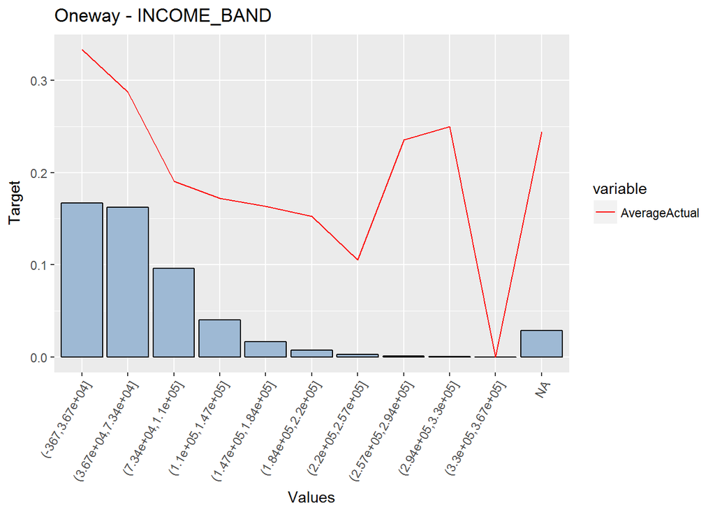

```
##
##
## [[4]]
## [[4]]$dframe
##         Factor SumWeight SumActual AverageActual
## 2  (0.976,3.4]      3707      1161     0.3131913
## 3    (3.4,5.8]      1686       445     0.2639383
## 4    (5.8,8.2]      2572       635     0.2468896
## 5   (8.2,10.6]      1246       262     0.2102729
## 1    (10.6,13]       709       159     0.2242595
## 8    (13,15.4]       132        28     0.2121212
## 6  (15.4,17.8]       176        41     0.2329545
## 7  (17.8,20.2]        49         5     0.1020408
## 9  (20.2,22.6]        16         4     0.2500000
## 10   (22.6,25]         3         0     0.0000000
##
## [[4]]$plot_table
```

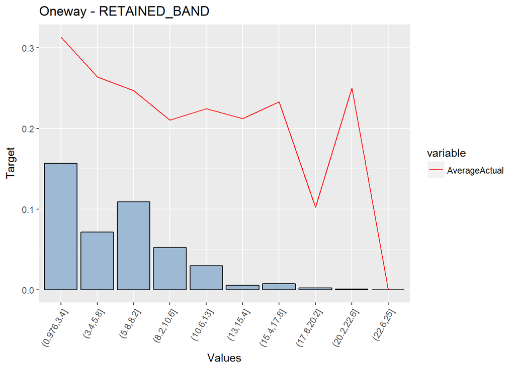

```
##
##
## [[5]]
## [[5]]$dframe
##         Factor SumWeight SumActual AverageActual
## 1 (-0.004,0.4]      9063      2248     0.2480415
## 2    (0.8,1.2]       804       312     0.3880597
## 3      (1.6,2]       351       139     0.3960114
## 4    (2.8,3.2]        74        39     0.5270270
## 5      (3.6,4]         4         2     0.5000000
##
## [[5]]$plot_table
```

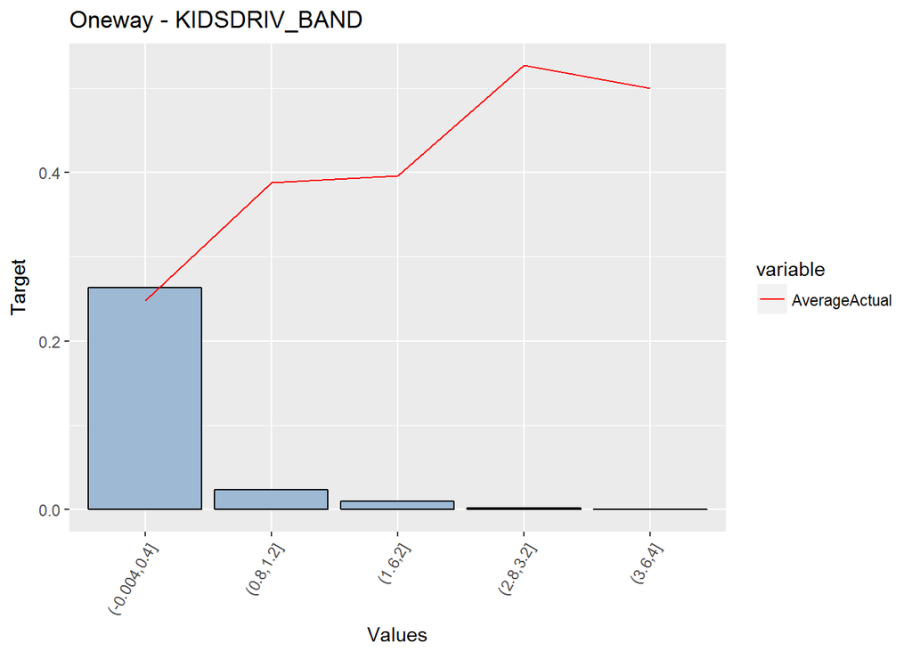

```
##
##
## [[6]]
## [[6]]$dframe
##         Factor SumWeight SumActual AverageActual
## 10 (-3.03,0.1]         5         2    0.40000000
## 2    (0.1,3.2]      2574       844    0.32789433
## 4    (3.2,6.3]      1079       298    0.27618165
## 5    (6.3,9.4]      2009       572    0.28471877
## 3   (9.4,12.5]      1616       384    0.23762376
## 6  (12.5,15.6]      1216       234    0.19243421
## 1  (15.6,18.7]       745       157    0.21073826
## 7  (18.7,21.8]       332        65    0.19578313
## 9  (21.8,24.9]        68         6    0.08823529
## 11   (24.9,28]        13         3    0.23076923
## 8         <NA>       639       175    0.27386541
##
## [[6]]$plot_table
```

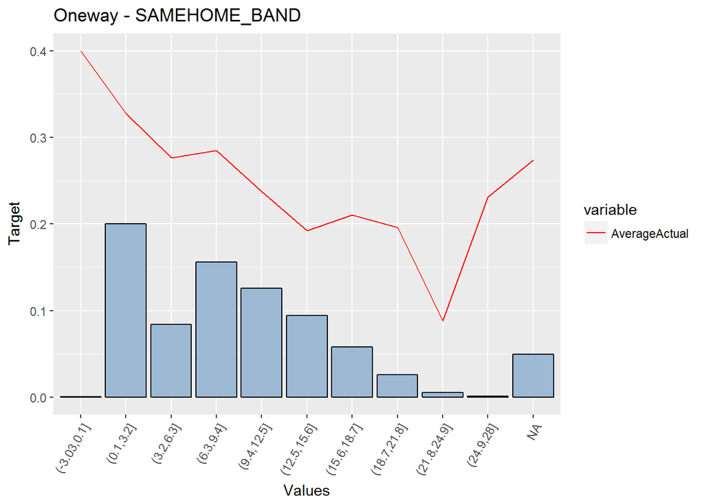

```r
# CHUNK 18
vars_to_band <- c("TRAVTIME", "AGE", "INCOME", "RETAINED", "KIDSDRIV", "SAMEHOME")
for (vble in vars_to_band) {
    newvar <- paste(vble, "BAND", sep = "_")
    AutoClaim[, newvar] <- cut(x = AutoClaim[, vble], breaks = 10, ordered_result = TRUE)
}

banded_vars <- c("TRAVTIME_BAND", "AGE_BAND", "INCOME_BAND", "RETAINED_BAND",
    "KIDSDRIV_BAND", "SAMEHOME_BAND")
lapply(X = banded_vars, FUN = function(x) {
    oneway_plot(dataset = AutoClaim, x = x, y = "CLM_FLAG_NUM")
})
```

Run CHUNK 19 to fit two GLMs. Note that the distribution function and link function are not specified. Choose one that makes sense to you for these initial models. Also, consider using other variables than those listed. There is no output.

```r
#CHUNK 19

glm.freq <- glm(formula = CLM_FLAG_NUM ~ AGE + GENDER + MARRIED + JOBCLASS + MAX_EDUC + BLUEBOOK,
                 data = AutoClaim,
                 family = poisson(link='log')) #xxx = poisson or binomial, yyy = log or logit. If binomial is used, an additional specification, weights=1 is needed

glm.sev <- glm(formula = CLM_AMT5 ~ AGE + GENDER + MARRIED + CAR_USE + BLUEBOOK + CAR_TYPE + AREA,
               # Keeping only observations with positive claim amounts
                 data = AutoClaim[which(AutoClaim$CLM_AMT5 > 0), ],
                 family = Gamma(link='log')) #zzz = Gamma or inverse.gaussian
```

Run CHUNK 20 to see the summary for your fitted frequency model.

```r
# CHUNK 20
summary(glm.freq)
```

```
##
## Call:
## glm(formula = CLM_FLAG_NUM ~ AGE + GENDER + MARRIED + JOBCLASS +
##     MAX_EDUC + BLUEBOOK, family = poisson(link = "log"), data = AutoClaim)
##
## Deviance Residuals:
##     Min       1Q   Median       3Q      Max
## -1.1488  -0.7477  -0.6100   0.5992   1.9055
##
## Coefficients:
##                        Estimate Std. Error z value Pr(>|z|)
## (Intercept)          -1.868e-01  1.694e-01  -1.103 0.270200
## AGE                  -8.524e-03  2.326e-03  -3.664 0.000248 ***
## GENDERM              -6.748e-02  4.033e-02  -1.673 0.094265 .
## MARRIEDYes           -4.273e-01  3.845e-02 -11.113  < 2e-16 ***
## JOBCLASSBlue Collar  -3.446e-02  1.272e-01  -0.271 0.786416
## JOBCLASSClerical     -2.491e-01  1.325e-01  -1.881 0.060038 .
## JOBCLASSDoctor       -8.622e-01  1.962e-01  -4.395 1.11e-05 ***
## JOBCLASSHome Maker   -3.213e-01  1.324e-01  -2.427 0.015245 *
## JOBCLASSLawyer       -4.673e-01  1.114e-01  -4.196 2.72e-05 ***
## JOBCLASSManager      -7.963e-01  1.224e-01  -6.508 7.61e-11 ***
## JOBCLASSProfessional -3.126e-01  1.238e-01  -2.524 0.011613 *
## JOBCLASSStudent      -5.928e-02  1.362e-01  -0.435 0.663343
## MAX_EDUCBachelors    -1.153e-01  6.533e-02  -1.765 0.077510 .
## MAX_EDUCHigh School   1.243e-01  5.551e-02   2.239 0.025180 *
## MAX_EDUCMasters      -1.611e-01  1.100e-01  -1.464 0.143268
## MAX_EDUCPhD          -1.982e-01  1.349e-01  -1.469 0.141883
## BLUEBOOK             -1.427e-05  2.621e-06  -5.444 5.21e-08 ***
## ---
## Signif. codes:  0 '***' 0.001 '**' 0.01 '*' 0.05 '.' 0.1 ' ' 1
##
## (Dispersion parameter for poisson family taken to be 1)
##
##     Null deviance: 7254.4  on 10295  degrees of freedom
## Residual deviance: 6768.6  on 10279  degrees of freedom
## AIC: 12283
##
## Number of Fisher Scoring iterations: 6
```

Run CHUNK 21 to see the exponentiated coefficients. These represent the muliplicative effect of a unit change in the variable.

```r
# CHUNK 21
exp(coef(glm.freq))
```

```
##          (Intercept)                  AGE              GENDERM
##            0.8295866            0.9915126            0.9347432
##           MARRIEDYes  JOBCLASSBlue Collar     JOBCLASSClerical
##            0.6522711            0.9661249            0.7795138
##       JOBCLASSDoctor   JOBCLASSHome Maker       JOBCLASSLawyer
##            0.4222459            0.7252257            0.6267115
##      JOBCLASSManager JOBCLASSProfessional      JOBCLASSStudent
##            0.4509911            0.7315761            0.9424445
##    MAX_EDUCBachelors  MAX_EDUCHigh School      MAX_EDUCMasters
##            0.8910710            1.1323238            0.8512370
##          MAX_EDUCPhD             BLUEBOOK
##            0.8202179            0.9999857
```

Run CHUNK 22 to obtain confidence intervals for the exponentiated coefficients.

```r
# CHUNK 22
exp(confint.default(glm.freq))
```

```
##                          2.5 %    97.5 %
## (Intercept)          0.5951574 1.1563561
## AGE                  0.9870022 0.9960436
## GENDERM              0.8637022 1.0116274
## MARRIEDYes           0.6049219 0.7033266
## JOBCLASSBlue Collar  0.7529669 1.2396259
## JOBCLASSClerical     0.6012807 1.0105792
## JOBCLASSDoctor       0.2874562 0.6202391
## JOBCLASSHome Maker   0.5594654 0.9400982
## JOBCLASSLawyer       0.5038187 0.7795805
## JOBCLASSManager      0.3548277 0.5732161
## JOBCLASSProfessional 0.5739043 0.9325659
## JOBCLASSStudent      0.7216748 1.2307506
## MAX_EDUCBachelors    0.7839747 1.0127975
## MAX_EDUCHigh School  1.0155896 1.2624758
## MAX_EDUCMasters      0.6860986 1.0561228
## MAX_EDUCPhD          0.6296188 1.0685153
## BLUEBOOK             0.9999806 0.9999909
```

Run CHUNK 23 to examine a reduced model.

```r
# CHUNK 23 Removed MAX_EDUC
glm.freq2 <- glm(formula = CLM_FLAG_NUM ~ AGE + GENDER + MARRIED + JOBCLASS +
    BLUEBOOK, data = AutoClaim, family = poisson(link = "log"))  #insert your earlier specifications

# anova(object, ..., dispersion = NULL, test = NULL) test - 'Chisq', 'LRT',
# 'Rao', 'F' or 'Cp'
anova(glm.freq, glm.freq2, test = "LRT")
```

```
## Analysis of Deviance Table
##
## Model 1: CLM_FLAG_NUM ~ AGE + GENDER + MARRIED + JOBCLASS + MAX_EDUC +
##     BLUEBOOK
## Model 2: CLM_FLAG_NUM ~ AGE + GENDER + MARRIED + JOBCLASS + BLUEBOOK
##   Resid. Df Resid. Dev Df Deviance  Pr(>Chi)
## 1     10279     6768.6
## 2     10283     6792.1 -4  -23.552 9.819e-05 ***
## ---
## Signif. codes:  0 '***' 0.001 '**' 0.01 '*' 0.05 '.' 0.1 ' ' 1
```

```r
# Drop 1 analysis
drop1(glm.freq, test = "LRT")
```

```
## Single term deletions
##
## Model:
## CLM_FLAG_NUM ~ AGE + GENDER + MARRIED + JOBCLASS + MAX_EDUC +
##     BLUEBOOK
##          Df Deviance   AIC     LRT  Pr(>Chi)
## <none>        6768.6 12283
## AGE       1   6782.0 12294  13.433 0.0002472 ***
## GENDER    1   6771.4 12283   2.804 0.0940429 .
## MARRIED   1   6891.3 12403 122.737 < 2.2e-16 ***
## JOBCLASS  8   6885.7 12384 117.130 < 2.2e-16 ***
## MAX_EDUC  4   6792.1 12298  23.552 9.819e-05 ***
## BLUEBOOK  1   6799.0 12311  30.401 3.514e-08 ***
## ---
## Signif. codes:  0 '***' 0.001 '**' 0.01 '*' 0.05 '.' 0.1 ' ' 1
```

Run CHUNK 24 to use AIC.

```r
# CHUNK 24
AIC(glm.freq, glm.freq2)
```

```
##           df      AIC
## glm.freq  17 12282.59
## glm.freq2 13 12298.15
```

```r
drop1(glm.freq)  #AIC is the default
```

```
## Single term deletions
##
## Model:
## CLM_FLAG_NUM ~ AGE + GENDER + MARRIED + JOBCLASS + MAX_EDUC +
##     BLUEBOOK
##          Df Deviance   AIC
## <none>        6768.6 12283
## AGE       1   6782.0 12294
## GENDER    1   6771.4 12283
## MARRIED   1   6891.3 12403
## JOBCLASS  8   6885.7 12384
## MAX_EDUC  4   6792.1 12298
## BLUEBOOK  1   6799.0 12311
```

…Okay. So looks like Gender might odd man out.

Let’s look at a drop-1 analysis with glm2.

```r
drop1(glm.freq2)  #AIC is the default
```

```
## Single term deletions
##
## Model:
## CLM_FLAG_NUM ~ AGE + GENDER + MARRIED + JOBCLASS + BLUEBOOK
##          Df Deviance   AIC
## <none>        6792.1 12298
## AGE       1   6806.8 12311
## GENDER    1   6795.0 12299
## MARRIED   1   6911.7 12416
## JOBCLASS  8   6997.8 12488
## BLUEBOOK  1   6826.7 12331
```

Same there as well. So maybe try a model with glm2 minus gender

```r
glm.freq3 <- glm(formula = CLM_FLAG_NUM ~ AGE + MARRIED + JOBCLASS + BLUEBOOK,
    data = AutoClaim, family = poisson(link = "log"))  #insert your earlier specifications
anova(glm.freq, glm.freq2, glm.freq3, test = "LRT")
```

```
## Analysis of Deviance Table
##
## Model 1: CLM_FLAG_NUM ~ AGE + GENDER + MARRIED + JOBCLASS + MAX_EDUC +
##     BLUEBOOK
## Model 2: CLM_FLAG_NUM ~ AGE + GENDER + MARRIED + JOBCLASS + BLUEBOOK
## Model 3: CLM_FLAG_NUM ~ AGE + MARRIED + JOBCLASS + BLUEBOOK
##   Resid. Df Resid. Dev Df Deviance  Pr(>Chi)
## 1     10279     6768.6
## 2     10283     6792.1 -4 -23.5525 9.819e-05 ***
## 3     10284     6795.0 -1  -2.8547   0.09111 .
## ---
## Signif. codes:  0 '***' 0.001 '**' 0.01 '*' 0.05 '.' 0.1 ' ' 1
```

```r
anova(glm.freq2, glm.freq3, test = "LRT")
```

```
## Analysis of Deviance Table
##
## Model 1: CLM_FLAG_NUM ~ AGE + GENDER + MARRIED + JOBCLASS + BLUEBOOK
## Model 2: CLM_FLAG_NUM ~ AGE + MARRIED + JOBCLASS + BLUEBOOK
##   Resid. Df Resid. Dev Df Deviance Pr(>Chi)
## 1     10283     6792.1
## 2     10284     6795.0 -1  -2.8547  0.09111 .
## ---
## Signif. codes:  0 '***' 0.001 '**' 0.01 '*' 0.05 '.' 0.1 ' ' 1
```

so final frequency model for now is: `CLM_FLAG_NUM ~ AGE + MARRIED + JOBCLASS + BLUEBOOK`

let’s look at severity model now. Initial formula was:  
`CLM_AMT5 ~ AGE + GENDER + MARRIED + CAR_USE + BLUEBOOK + CAR_TYPE + AREA`

Let’s do some diagnostics.

First let’s look at summary of the fit.

```r
# CHUNK 20
summary(glm.sev)
```

```
##
## Call:
## glm(formula = CLM_AMT5 ~ AGE + GENDER + MARRIED + CAR_USE + BLUEBOOK +
##     CAR_TYPE + AREA, family = Gamma(link = "log"), data = AutoClaim[which(AutoClaim$CLM_AMT5 >
##     0), ])
##
## Deviance Residuals:
##      Min        1Q    Median        3Q       Max
## -2.07543  -0.88815  -0.49741  -0.05211   2.48048
##
## Coefficients:
##                      Estimate Std. Error t value Pr(>|t|)
## (Intercept)         9.141e+00  1.648e-01  55.459   <2e-16 ***
## AGE                -1.223e-03  1.966e-03  -0.622   0.5339
## GENDERM             3.164e-02  5.803e-02   0.545   0.5856
## MARRIEDYes         -1.102e-02  3.520e-02  -0.313   0.7543
## CAR_USECommercial  -3.459e-02  4.228e-02  -0.818   0.4134
## BLUEBOOK            3.454e-06  2.940e-06   1.175   0.2401
## CAR_TYPEPickup      1.689e-01  8.938e-02   1.890   0.0589 .
## CAR_TYPESedan       1.957e-01  8.832e-02   2.215   0.0268 *
## CAR_TYPESports Car  2.906e-01  1.192e-01   2.439   0.0148 *
## CAR_TYPESUV         1.774e-01  1.116e-01   1.589   0.1121
## CAR_TYPEVan         2.151e-01  8.544e-02   2.517   0.0119 *
## AREAUrban          -7.660e-02  7.215e-02  -1.062   0.2885
## ---
## Signif. codes:  0 '***' 0.001 '**' 0.01 '*' 0.05 '.' 0.1 ' ' 1
##
## (Dispersion parameter for Gamma family taken to be 1.210621)
##
##     Null deviance: 3911.9  on 4005  degrees of freedom
## Residual deviance: 3893.9  on 3994  degrees of freedom
## AIC: 82080
##
## Number of Fisher Scoring iterations: 6
```

Hmm. only a few considered significant…basically Car type

let’s confirm by looking at the coefficients

```r
# CHUNK 22
exp(confint.default(glm.sev))
```

```
##                           2.5 %       97.5 %
## (Intercept)        6754.7921440 12888.844974
## AGE                   0.9949363     1.002634
## GENDERM               0.9211873     1.156462
## MARRIEDYes            0.9231105     1.059685
## CAR_USECommercial     0.8891878     1.049459
## BLUEBOOK              0.9999977     1.000009
## CAR_TYPEPickup        0.9937455     1.410716
## CAR_TYPESedan         1.0228204     1.445978
## CAR_TYPESports Car    1.0587244     1.689025
## CAR_TYPESUV           0.9594668     1.486102
## CAR_TYPEVan           1.0487752     1.466005
## AREAUrban             0.8041119     1.066969
```

Nothing too telling, expect may BLUEBOOK. so narrow, basically says has no effect.

Let’s remove Gender and do an ANOVA.

```r
glm.sev2 <- glm(formula = CLM_AMT5 ~ AGE + MARRIED + CAR_USE + BLUEBOOK + CAR_TYPE + AREA,
               # Keeping only observations with positive claim amounts
                 data = AutoClaim[which(AutoClaim$CLM_AMT5 > 0), ],
                 family = Gamma(link='log')) #zzz = Gamma or inverse.gaussian
anova(glm.sev, glm.sev2, test = "LRT")
```

```
## Analysis of Deviance Table
##
## Model 1: CLM_AMT5 ~ AGE + GENDER + MARRIED + CAR_USE + BLUEBOOK + CAR_TYPE +
##     AREA
## Model 2: CLM_AMT5 ~ AGE + MARRIED + CAR_USE + BLUEBOOK + CAR_TYPE + AREA
##   Resid. Df Resid. Dev Df Deviance Pr(>Chi)
## 1      3994     3893.9
## 2      3995     3894.2 -1 -0.35255   0.5894
```

makes sense. Basically worthless. Keep peeling

```r
summary(glm.sev2)
```

```
##
## Call:
## glm(formula = CLM_AMT5 ~ AGE + MARRIED + CAR_USE + BLUEBOOK +
##     CAR_TYPE + AREA, family = Gamma(link = "log"), data = AutoClaim[which(AutoClaim$CLM_AMT5 >
##     0), ])
##
## Deviance Residuals:
##      Min        1Q    Median        3Q       Max
## -2.07583  -0.88796  -0.49869  -0.05147   2.48047
##
## Coefficients:
##                      Estimate Std. Error t value Pr(>|t|)
## (Intercept)         9.183e+00  1.464e-01  62.728  < 2e-16 ***
## AGE                -1.057e-03  1.943e-03  -0.544  0.58637
## MARRIEDYes         -1.199e-02  3.520e-02  -0.341  0.73332
## CAR_USECommercial  -3.438e-02  4.228e-02  -0.813  0.41617
## BLUEBOOK            2.801e-06  2.687e-06   1.042  0.29730
## CAR_TYPEPickup      1.516e-01  8.353e-02   1.815  0.06960 .
## CAR_TYPESedan       1.792e-01  8.314e-02   2.156  0.03117 *
## CAR_TYPESports Car  2.506e-01  9.378e-02   2.672  0.00758 **
## CAR_TYPESUV         1.378e-01  8.561e-02   1.609  0.10762
## CAR_TYPEVan         2.084e-01  8.448e-02   2.466  0.01369 *
## AREAUrban          -7.676e-02  7.216e-02  -1.064  0.28750
## ---
## Signif. codes:  0 '***' 0.001 '**' 0.01 '*' 0.05 '.' 0.1 ' ' 1
##
## (Dispersion parameter for Gamma family taken to be 1.21093)
##
##     Null deviance: 3911.9  on 4005  degrees of freedom
## Residual deviance: 3894.2  on 3995  degrees of freedom
## AIC: 82078
##
## Number of Fisher Scoring iterations: 5
```

remove married

```r
glm.sev3 <- glm(formula = CLM_AMT5 ~ AGE + CAR_USE + BLUEBOOK + CAR_TYPE + AREA,
               # Keeping only observations with positive claim amounts
                 data = AutoClaim[which(AutoClaim$CLM_AMT5 > 0), ],
                 family = Gamma(link='log')) #zzz = Gamma or inverse.gaussian
anova(glm.sev2, glm.sev3, test = "LRT")
```

```
## Analysis of Deviance Table
##
## Model 1: CLM_AMT5 ~ AGE + MARRIED + CAR_USE + BLUEBOOK + CAR_TYPE + AREA
## Model 2: CLM_AMT5 ~ AGE + CAR_USE + BLUEBOOK + CAR_TYPE + AREA
##   Resid. Df Resid. Dev Df Deviance Pr(>Chi)
## 1      3995     3894.2
## 2      3996     3894.4 -1 -0.14022   0.7336
```

Keep going!

```r
summary(glm.sev3)
```

```
##
## Call:
## glm(formula = CLM_AMT5 ~ AGE + CAR_USE + BLUEBOOK + CAR_TYPE +
##     AREA, family = Gamma(link = "log"), data = AutoClaim[which(AutoClaim$CLM_AMT5 >
##     0), ])
##
## Deviance Residuals:
##      Min        1Q    Median        3Q       Max
## -2.07855  -0.88787  -0.49840  -0.05458   2.49152
##
## Coefficients:
##                      Estimate Std. Error t value Pr(>|t|)
## (Intercept)         9.179e+00  1.461e-01  62.829  < 2e-16 ***
## AGE                -1.127e-03  1.934e-03  -0.583  0.56023
## CAR_USECommercial  -3.473e-02  4.225e-02  -0.822  0.41107
## BLUEBOOK            2.809e-06  2.687e-06   1.046  0.29583
## CAR_TYPEPickup      1.512e-01  8.352e-02   1.810  0.07036 .
## CAR_TYPESedan       1.788e-01  8.313e-02   2.151  0.03150 *
## CAR_TYPESports Car  2.498e-01  9.374e-02   2.665  0.00774 **
## CAR_TYPESUV         1.369e-01  8.560e-02   1.600  0.10970
## CAR_TYPEVan         2.087e-01  8.448e-02   2.471  0.01353 *
## AREAUrban          -7.638e-02  7.215e-02  -1.059  0.28982
## ---
## Signif. codes:  0 '***' 0.001 '**' 0.01 '*' 0.05 '.' 0.1 ' ' 1
##
## (Dispersion parameter for Gamma family taken to be 1.210863)
##
##     Null deviance: 3911.9  on 4005  degrees of freedom
## Residual deviance: 3894.4  on 3996  degrees of freedom
## AIC: 82076
##
## Number of Fisher Scoring iterations: 5
```

CAR_USE

```r
glm.sev4 <- glm(formula = CLM_AMT5 ~ AGE + BLUEBOOK + CAR_TYPE + AREA,
               # Keeping only observations with positive claim amounts
                 data = AutoClaim[which(AutoClaim$CLM_AMT5 > 0), ],
                 family = Gamma(link='log')) #zzz = Gamma or inverse.gaussian
anova(glm.sev3, glm.sev4, test = "LRT")
```

```
## Analysis of Deviance Table
##
## Model 1: CLM_AMT5 ~ AGE + CAR_USE + BLUEBOOK + CAR_TYPE + AREA
## Model 2: CLM_AMT5 ~ AGE + BLUEBOOK + CAR_TYPE + AREA
##   Resid. Df Resid. Dev Df Deviance Pr(>Chi)
## 1      3996     3894.4
## 2      3997     3895.2 -1 -0.82906    0.408
```

Keep going.

```r
summary(glm.sev4)
```

```
##
## Call:
## glm(formula = CLM_AMT5 ~ AGE + BLUEBOOK + CAR_TYPE + AREA, family = Gamma(link = "log"),
##     data = AutoClaim[which(AutoClaim$CLM_AMT5 > 0), ])
##
## Deviance Residuals:
##      Min        1Q    Median        3Q       Max
## -2.07482  -0.89081  -0.49594  -0.05459   2.49229
##
## Coefficients:
##                      Estimate Std. Error t value Pr(>|t|)
## (Intercept)         9.142e+00  1.386e-01  65.967  < 2e-16 ***
## AGE                -1.049e-03  1.933e-03  -0.543  0.58748
## BLUEBOOK            2.728e-06  2.686e-06   1.015  0.30995
## CAR_TYPEPickup      1.621e-01  8.238e-02   1.967  0.04923 *
## CAR_TYPESedan       2.039e-01  7.711e-02   2.644  0.00824 **
## CAR_TYPESports Car  2.756e-01  8.738e-02   3.154  0.00162 **
## CAR_TYPESUV         1.633e-01  7.909e-02   2.065  0.03902 *
## CAR_TYPEVan         2.198e-01  8.344e-02   2.635  0.00846 **
## AREAUrban          -7.446e-02  7.211e-02  -1.033  0.30183
## ---
## Signif. codes:  0 '***' 0.001 '**' 0.01 '*' 0.05 '.' 0.1 ' ' 1
##
## (Dispersion parameter for Gamma family taken to be 1.210572)
##
##     Null deviance: 3911.9  on 4005  degrees of freedom
## Residual deviance: 3895.2  on 3997  degrees of freedom
## AIC: 82075
##
## Number of Fisher Scoring iterations: 5
```

Blue Book.

```r
glm.sev5 <- glm(formula = CLM_AMT5 ~ AGE + CAR_TYPE + AREA,
               # Keeping only observations with positive claim amounts
                 data = AutoClaim[which(AutoClaim$CLM_AMT5 > 0), ],
                 family = Gamma(link='log')) #zzz = Gamma or inverse.gaussian
anova(glm.sev4, glm.sev5, test = "LRT")
```

```
## Analysis of Deviance Table
##
## Model 1: CLM_AMT5 ~ AGE + BLUEBOOK + CAR_TYPE + AREA
## Model 2: CLM_AMT5 ~ AGE + CAR_TYPE + AREA
##   Resid. Df Resid. Dev Df Deviance Pr(>Chi)
## 1      3997     3895.2
## 2      3998     3896.5 -1   -1.246   0.3103
```

Keep going.

```r
summary(glm.sev5)
```

```
##
## Call:
## glm(formula = CLM_AMT5 ~ AGE + CAR_TYPE + AREA, family = Gamma(link = "log"),
##     data = AutoClaim[which(AutoClaim$CLM_AMT5 > 0), ])
##
## Deviance Residuals:
##     Min       1Q   Median       3Q      Max
## -2.0780  -0.8901  -0.4916  -0.0539   2.4724
##
## Coefficients:
##                      Estimate Std. Error t value Pr(>|t|)
## (Intercept)         9.2076555  0.1240644  74.217  < 2e-16 ***
## AGE                -0.0008349  0.0019142  -0.436  0.66275
## CAR_TYPEPickup      0.1177553  0.0708006   1.663  0.09635 .
## CAR_TYPESedan       0.1676375  0.0685155   2.447  0.01446 *
## CAR_TYPESports Car  0.2277032  0.0745369   3.055  0.00227 **
## CAR_TYPESUV         0.1172286  0.0660075   1.776  0.07581 .
## CAR_TYPEVan         0.1955533  0.0806562   2.425  0.01537 *
## AREAUrban          -0.0705299  0.0720253  -0.979  0.32752
## ---
## Signif. codes:  0 '***' 0.001 '**' 0.01 '*' 0.05 '.' 0.1 ' ' 1
##
## (Dispersion parameter for Gamma family taken to be 1.21005)
##
##     Null deviance: 3911.9  on 4005  degrees of freedom
## Residual deviance: 3896.5  on 3998  degrees of freedom
## AIC: 82075
##
## Number of Fisher Scoring iterations: 5
```

AGE

```r
glm.sev6 <- glm(formula = CLM_AMT5 ~ CAR_TYPE + AREA,
               # Keeping only observations with positive claim amounts
                 data = AutoClaim[which(AutoClaim$CLM_AMT5 > 0), ],
                 family = Gamma(link='log')) #zzz = Gamma or inverse.gaussian
anova(glm.sev5, glm.sev6, test = "LRT")
```

```
## Analysis of Deviance Table
##
## Model 1: CLM_AMT5 ~ AGE + CAR_TYPE + AREA
## Model 2: CLM_AMT5 ~ CAR_TYPE + AREA
##   Resid. Df Resid. Dev Df Deviance Pr(>Chi)
## 1      3998     3896.5
## 2      3999     3896.7 -1 -0.22412   0.6669
```

We’re going to run out of features!

```r
summary(glm.sev6)
```

```
##
## Call:
## glm(formula = CLM_AMT5 ~ CAR_TYPE + AREA, family = Gamma(link = "log"),
##     data = AutoClaim[which(AutoClaim$CLM_AMT5 > 0), ])
##
## Deviance Residuals:
##      Min        1Q    Median        3Q       Max
## -2.07504  -0.88901  -0.49344  -0.05971   2.48991
##
## Coefficients:
##                    Estimate Std. Error t value Pr(>|t|)
## (Intercept)         9.17032    0.08994 101.959  < 2e-16 ***
## CAR_TYPEPickup      0.11947    0.07062   1.692  0.09080 .
## CAR_TYPESedan       0.16901    0.06834   2.473  0.01344 *
## CAR_TYPESports Car  0.22790    0.07451   3.059  0.00224 **
## CAR_TYPESUV         0.11904    0.06579   1.809  0.07047 .
## CAR_TYPEVan         0.19633    0.08061   2.435  0.01492 *
## AREAUrban          -0.07141    0.07194  -0.993  0.32099
## ---
## Signif. codes:  0 '***' 0.001 '**' 0.01 '*' 0.05 '.' 0.1 ' ' 1
##
## (Dispersion parameter for Gamma family taken to be 1.21031)
##
##     Null deviance: 3911.9  on 4005  degrees of freedom
## Residual deviance: 3896.7  on 3999  degrees of freedom
## AIC: 82073
##
## Number of Fisher Scoring iterations: 5
```

Only one left is AREA.

```r
glm.sev7 <- glm(formula = CLM_AMT5 ~ CAR_TYPE,
               # Keeping only observations with positive claim amounts
                 data = AutoClaim[which(AutoClaim$CLM_AMT5 > 0), ],
                 family = Gamma(link='log')) #zzz = Gamma or inverse.gaussian
anova(glm.sev6, glm.sev7, test = "LRT")
```

```
## Analysis of Deviance Table
##
## Model 1: CLM_AMT5 ~ CAR_TYPE + AREA
## Model 2: CLM_AMT5 ~ CAR_TYPE
##   Resid. Df Resid. Dev Df Deviance Pr(>Chi)
## 1      3999     3896.7
## 2      4000     3897.9 -1  -1.2187   0.3156
```

OK. Let’s compare this last model to the original.

```r
anova(glm.sev, glm.sev7, test = "LRT")
```

```
## Analysis of Deviance Table
##
## Model 1: CLM_AMT5 ~ AGE + GENDER + MARRIED + CAR_USE + BLUEBOOK + CAR_TYPE +
##     AREA
## Model 2: CLM_AMT5 ~ CAR_TYPE
##   Resid. Df Resid. Dev Df Deviance Pr(>Chi)
## 1      3994     3893.9
## 2      4000     3897.9 -6  -4.0107   0.7687
```

Only lose 4 deviance points and remove all but one feature? I’ll take it!

##### Per Ex 6.6.10:

Add some interactions to your auto claim frequency model, and determine if they have improved the model.

Recall:

```r
summary(glm.freq)
```

```
##
## Call:
## glm(formula = CLM_FLAG_NUM ~ AGE + GENDER + MARRIED + JOBCLASS +
##     MAX_EDUC + BLUEBOOK, family = poisson(link = "log"), data = AutoClaim)
##
## Deviance Residuals:
##     Min       1Q   Median       3Q      Max
## -1.1488  -0.7477  -0.6100   0.5992   1.9055
##
## Coefficients:
##                        Estimate Std. Error z value Pr(>|z|)
## (Intercept)          -1.868e-01  1.694e-01  -1.103 0.270200
## AGE                  -8.524e-03  2.326e-03  -3.664 0.000248 ***
## GENDERM              -6.748e-02  4.033e-02  -1.673 0.094265 .
## MARRIEDYes           -4.273e-01  3.845e-02 -11.113  < 2e-16 ***
## JOBCLASSBlue Collar  -3.446e-02  1.272e-01  -0.271 0.786416
## JOBCLASSClerical     -2.491e-01  1.325e-01  -1.881 0.060038 .
## JOBCLASSDoctor       -8.622e-01  1.962e-01  -4.395 1.11e-05 ***
## JOBCLASSHome Maker   -3.213e-01  1.324e-01  -2.427 0.015245 *
## JOBCLASSLawyer       -4.673e-01  1.114e-01  -4.196 2.72e-05 ***
## JOBCLASSManager      -7.963e-01  1.224e-01  -6.508 7.61e-11 ***
## JOBCLASSProfessional -3.126e-01  1.238e-01  -2.524 0.011613 *
## JOBCLASSStudent      -5.928e-02  1.362e-01  -0.435 0.663343
## MAX_EDUCBachelors    -1.153e-01  6.533e-02  -1.765 0.077510 .
## MAX_EDUCHigh School   1.243e-01  5.551e-02   2.239 0.025180 *
## MAX_EDUCMasters      -1.611e-01  1.100e-01  -1.464 0.143268
## MAX_EDUCPhD          -1.982e-01  1.349e-01  -1.469 0.141883
## BLUEBOOK             -1.427e-05  2.621e-06  -5.444 5.21e-08 ***
## ---
## Signif. codes:  0 '***' 0.001 '**' 0.01 '*' 0.05 '.' 0.1 ' ' 1
##
## (Dispersion parameter for poisson family taken to be 1)
##
##     Null deviance: 7254.4  on 10295  degrees of freedom
## Residual deviance: 6768.6  on 10279  degrees of freedom
## AIC: 12283
##
## Number of Fisher Scoring iterations: 6
```

Perhaps, while gender doesn’t seem to have a relationship with being a claimant, maybe the interation with age does…?

```r
glm.freq.int.1 <- glm(formula = CLM_FLAG_NUM ~ AGE + AGE * GENDER + MARRIED +
    JOBCLASS + MAX_EDUC + BLUEBOOK, data = AutoClaim, family = poisson(link = "log"))  #xxx = poisson or binomial, yyy = log or logit. If binomial is used, an additional specification, weights=1 is needed
summary(glm.freq.int.1)
```

```
##
## Call:
## glm(formula = CLM_FLAG_NUM ~ AGE + AGE * GENDER + MARRIED + JOBCLASS +
##     MAX_EDUC + BLUEBOOK, family = poisson(link = "log"), data = AutoClaim)
##
## Deviance Residuals:
##     Min       1Q   Median       3Q      Max
## -1.1943  -0.7479  -0.6101   0.5983   1.9244
##
## Coefficients:
##                        Estimate Std. Error z value Pr(>|z|)
## (Intercept)          -2.948e-01  1.862e-01  -1.583  0.11337
## AGE                  -5.690e-03  3.070e-03  -1.853  0.06383 .
## GENDERM               2.066e-01  1.980e-01   1.043  0.29681
## MARRIEDYes           -4.267e-01  3.846e-02 -11.097  < 2e-16 ***
## JOBCLASSBlue Collar  -4.502e-02  1.274e-01  -0.353  0.72372
## JOBCLASSClerical     -2.615e-01  1.327e-01  -1.970  0.04882 *
## JOBCLASSDoctor       -8.708e-01  1.963e-01  -4.436 9.18e-06 ***
## JOBCLASSHome Maker   -3.345e-01  1.326e-01  -2.522  0.01167 *
## JOBCLASSLawyer       -4.767e-01  1.116e-01  -4.272 1.94e-05 ***
## JOBCLASSManager      -8.051e-01  1.226e-01  -6.569 5.08e-11 ***
## JOBCLASSProfessional -3.232e-01  1.241e-01  -2.604  0.00921 **
## JOBCLASSStudent      -7.256e-02  1.365e-01  -0.532  0.59496
## MAX_EDUCBachelors    -1.172e-01  6.535e-02  -1.794  0.07284 .
## MAX_EDUCHigh School   1.227e-01  5.553e-02   2.210  0.02713 *
## MAX_EDUCMasters      -1.662e-01  1.101e-01  -1.509  0.13124
## MAX_EDUCPhD          -2.042e-01  1.349e-01  -1.513  0.13019
## BLUEBOOK             -1.431e-05  2.621e-06  -5.460 4.77e-08 ***
## AGE:GENDERM          -6.335e-03  4.484e-03  -1.413  0.15771
## ---
## Signif. codes:  0 '***' 0.001 '**' 0.01 '*' 0.05 '.' 0.1 ' ' 1
##
## (Dispersion parameter for poisson family taken to be 1)
##
##     Null deviance: 7254.4  on 10295  degrees of freedom
## Residual deviance: 6766.6  on 10278  degrees of freedom
## AIC: 12283
##
## Number of Fisher Scoring iterations: 6
```

```r
anova(glm.freq, glm.freq.int.1, test = "LRT")
```

```
## Analysis of Deviance Table
##
## Model 1: CLM_FLAG_NUM ~ AGE + GENDER + MARRIED + JOBCLASS + MAX_EDUC +
##     BLUEBOOK
## Model 2: CLM_FLAG_NUM ~ AGE + AGE * GENDER + MARRIED + JOBCLASS + MAX_EDUC +
##     BLUEBOOK
##   Resid. Df Resid. Dev Df Deviance Pr(>Chi)
## 1     10279     6768.6
## 2     10278     6766.6  1   1.9945   0.1579
```

hmm. A smidge better, deviance-wise, but the actual coef is not considered signficant.

How about gender and Max education?

```r
glm.freq.int.2 <- glm(formula = CLM_FLAG_NUM ~ AGE + MAX_EDUC * GENDER + MARRIED +
    JOBCLASS + BLUEBOOK, data = AutoClaim, family = poisson(link = "log"))  #xxx = poisson or binomial, yyy = log or logit. If binomial is used, an additional specification, weights=1 is needed
summary(glm.freq.int.2)
```

```
##
## Call:
## glm(formula = CLM_FLAG_NUM ~ AGE + MAX_EDUC * GENDER + MARRIED +
##     JOBCLASS + BLUEBOOK, family = poisson(link = "log"), data = AutoClaim)
##
## Deviance Residuals:
##     Min       1Q   Median       3Q      Max
## -1.1566  -0.7490  -0.6099   0.5995   1.9821
##
## Coefficients:
##                               Estimate Std. Error z value Pr(>|z|)
## (Intercept)                 -1.243e-01  1.746e-01  -0.712  0.47630
## AGE                         -8.466e-03  2.324e-03  -3.642  0.00027 ***
## MAX_EDUCBachelors           -1.129e-01  8.443e-02  -1.337  0.18127
## MAX_EDUCHigh School          1.493e-01  7.404e-02   2.016  0.04378 *
## MAX_EDUCMasters             -7.393e-02  1.247e-01  -0.593  0.55331
## MAX_EDUCPhD                 -5.457e-02  1.551e-01  -0.352  0.72496
## GENDERM                      1.013e-02  9.141e-02   0.111  0.91179
## MARRIEDYes                  -4.281e-01  3.846e-02 -11.131  < 2e-16 ***
## JOBCLASSBlue Collar         -1.317e-01  1.323e-01  -0.996  0.31936
## JOBCLASSClerical            -3.448e-01  1.371e-01  -2.514  0.01192 *
## JOBCLASSDoctor              -9.516e-01  1.997e-01  -4.765 1.89e-06 ***
## JOBCLASSHome Maker          -4.141e-01  1.361e-01  -3.042  0.00235 **
## JOBCLASSLawyer              -5.494e-01  1.163e-01  -4.723 2.33e-06 ***
## JOBCLASSManager             -8.840e-01  1.272e-01  -6.952 3.59e-12 ***
## JOBCLASSProfessional        -4.024e-01  1.287e-01  -3.127  0.00176 **
## JOBCLASSStudent             -1.552e-01  1.408e-01  -1.102  0.27041
## BLUEBOOK                    -1.451e-05  2.623e-06  -5.532 3.16e-08 ***
## MAX_EDUCBachelors:GENDERM   -1.060e-02  1.195e-01  -0.089  0.92932
## MAX_EDUCHigh School:GENDERM -5.595e-02  1.109e-01  -0.505  0.61374
## MAX_EDUCMasters:GENDERM     -2.519e-01  1.392e-01  -1.810  0.07028 .
## MAX_EDUCPhD:GENDERM         -3.941e-01  1.905e-01  -2.068  0.03860 *
## ---
## Signif. codes:  0 '***' 0.001 '**' 0.01 '*' 0.05 '.' 0.1 ' ' 1
##
## (Dispersion parameter for poisson family taken to be 1)
##
##     Null deviance: 7254.4  on 10295  degrees of freedom
## Residual deviance: 6761.0  on 10275  degrees of freedom
## AIC: 12283
##
## Number of Fisher Scoring iterations: 6
```

```r
anova(glm.freq, glm.freq.int.1, glm.freq.int.2, test = "LRT")
```

```
## Analysis of Deviance Table
##
## Model 1: CLM_FLAG_NUM ~ AGE + GENDER + MARRIED + JOBCLASS + MAX_EDUC +
##     BLUEBOOK
## Model 2: CLM_FLAG_NUM ~ AGE + AGE * GENDER + MARRIED + JOBCLASS + MAX_EDUC +
##     BLUEBOOK
## Model 3: CLM_FLAG_NUM ~ AGE + MAX_EDUC * GENDER + MARRIED + JOBCLASS +
##     BLUEBOOK
##   Resid. Df Resid. Dev Df Deviance Pr(>Chi)
## 1     10279     6768.6
## 2     10278     6766.6  1   1.9945   0.1579
## 3     10275     6761.0  3   5.6000   0.1328
```

That one is alittle more helpful.

Let’s compare with the prior ‘best’ model, `glm.freq3’

```r
glm.freq1b <- glm(formula = CLM_FLAG_NUM ~ AGE + MARRIED + JOBCLASS + MAX_EDUC +
    BLUEBOOK, data = AutoClaim, family = poisson(link = "log"))  #insert your earlier specifications

anova(glm.freq3, glm.freq.int.2, glm.freq1b, test = "LRT")
```

```
## Analysis of Deviance Table
##
## Model 1: CLM_FLAG_NUM ~ AGE + MARRIED + JOBCLASS + BLUEBOOK
## Model 2: CLM_FLAG_NUM ~ AGE + MAX_EDUC * GENDER + MARRIED + JOBCLASS +
##     BLUEBOOK
## Model 3: CLM_FLAG_NUM ~ AGE + MARRIED + JOBCLASS + MAX_EDUC + BLUEBOOK
##   Resid. Df Resid. Dev Df Deviance  Pr(>Chi)
## 1     10284     6795.0
## 2     10275     6761.0  9   34.002 8.926e-05 ***
## 3     10280     6771.4 -5  -10.398   0.06471 .
## ---
## Signif. codes:  0 '***' 0.001 '**' 0.01 '*' 0.05 '.' 0.1 ' ' 1
```

```r
# Or calculate the change in AIC between the two models (with and without
# the interaction)
AIC(glm.freq.int.2) - AIC(glm.freq3)
```

```
## [1] -16.00163
```

```r
AIC(glm.freq.int.2) - AIC(glm.freq1b)
```

```
## [1] -0.3982181
```

So, yes adding the interation of max education with gender improves the model a little.